# Part II - (Ford GoBike System Data)

## by (John Kwame Dunyo)

## Investigation Overview

For the presentation, I focus on trip duration and trip count. I start by finding the relationship between user characteristics & trip count by presenting different type of visualization (Histogram, Pie Chart & Bar Plot). Then I found the relation between trip duration and user characteristics like (member age & user type).

## Dataset Overview

The dataset used in this project is from the Ford GoBike Systems. It includes information about individual rides made in a bike-sharing system covering the greater San Francisco Bay area.

## Ride Distribution By User Type

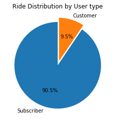

## Ride Distribution by Gender

Male dominates predominantly with 74.6% of the total trips. Females took 23.3% and the rest being other gender

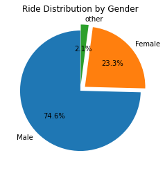

## Ride Distribution By Age

The most bike trips are for members between 25-55 years old , and the number of trips gradually decreases as the age increases.

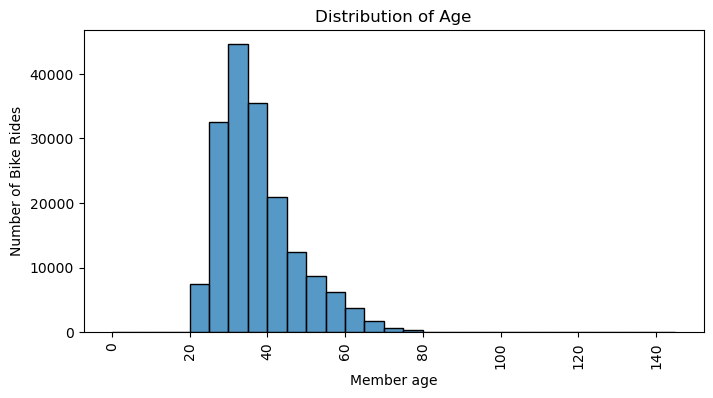

## Ride duration per Weekdays

There is a stable bike use along weekdays 5 to 10 minutes. However, the trip duration is longer during weekends, reflecting more casual usages.ie 5 to 15 minutes

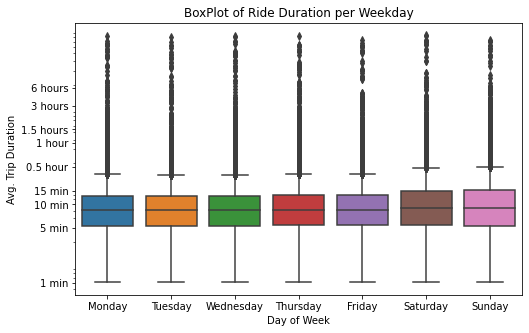

## Ride Duration Comapared to User Type

Subscribers tend to have less average ride times compared to normal customers. This may mean that most of the subscribers are using the system to comute to and from work/school, with the same round trip time everyday.

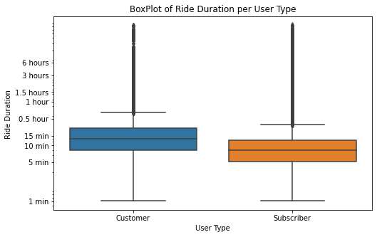

## Hourly Usage during Weekdays for Customers and Subscribers

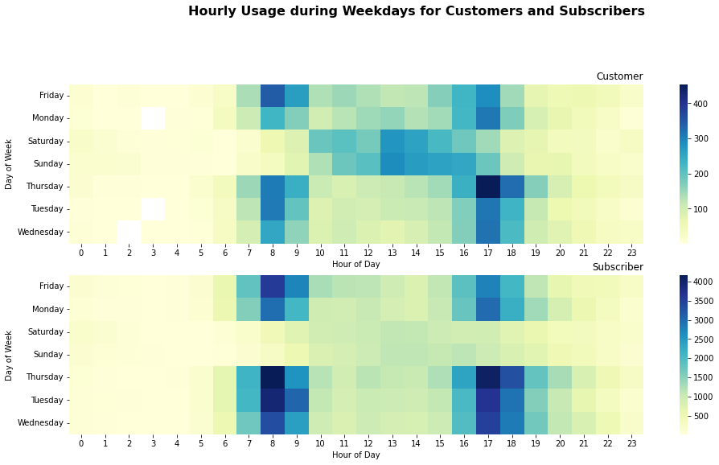